# Intern_test_Dmitry_Bannikov

```python
import numpy as np
import pandas as pd
import seaborn as sns
import scipy
from tqdm import tqdm_notebook

%matplotlib inline
from matplotlib import pyplot as plt

plt.style.use(['seaborn-darkgrid'])
plt.rcParams['figure.figsize'] = (12, 9)
plt.rcParams['font.family'] = 'DejaVu Sans'

from sklearn import metrics
from sklearn.model_selection import GridSearchCV
from sklearn.model_selection import train_test_split
from catboost import CatBoostRegressor
from sklearn.metrics import mean_absolute_error, mean_squared_error
from sklearn.model_selection import cross_val_score

import os
```

## A. Dataset

Будем работать с time-series данными

```python
data = pd.read_csv('energydata_complete.csv')
```

```python
data.head()
```

|  | date | Appliances | lights | T1 | RH_1 | T2 | RH_2 | T3 | RH_3 | T4 | ... | T9 | RH_9 | T_out | Press_mm_hg | RH_out | Windspeed | Visibility | Tdewpoint | rv1 | rv2 |
| --- | --- | --- | --- | --- | --- | --- | --- | --- | --- | --- | --- | --- | --- | --- | --- | --- | --- | --- | --- | --- | --- |
| 0 | 2016-01-11 17:00:00 | 60 | 30 | 19.89 | 47.596667 | 19.2 | 44.790000 | 19.79 | 44.730000 | 19.000000 | ... | 17.033333 | 45.53 | 6.600000 | 733.5 | 92.0 | 7.000000 | 63.000000 | 5.3 | 13.275433 | 13.275433 |
| 1 | 2016-01-11 17:10:00 | 60 | 30 | 19.89 | 46.693333 | 19.2 | 44.722500 | 19.79 | 44.790000 | 19.000000 | ... | 17.066667 | 45.56 | 6.483333 | 733.6 | 92.0 | 6.666667 | 59.166667 | 5.2 | 18.606195 | 18.606195 |
| 2 | 2016-01-11 17:20:00 | 50 | 30 | 19.89 | 46.300000 | 19.2 | 44.626667 | 19.79 | 44.933333 | 18.926667 | ... | 17.000000 | 45.50 | 6.366667 | 733.7 | 92.0 | 6.333333 | 55.333333 | 5.1 | 28.642668 | 28.642668 |
| 3 | 2016-01-11 17:30:00 | 50 | 40 | 19.89 | 46.066667 | 19.2 | 44.590000 | 19.79 | 45.000000 | 18.890000 | ... | 17.000000 | 45.40 | 6.250000 | 733.8 | 92.0 | 6.000000 | 51.500000 | 5.0 | 45.410389 | 45.410389 |
| 4 | 2016-01-11 17:40:00 | 60 | 40 | 19.89 | 46.333333 | 19.2 | 44.530000 | 19.79 | 45.000000 | 18.890000 | ... | 17.000000 | 45.40 | 6.133333 | 733.9 | 92.0 | 5.666667 | 47.666667 | 4.9 | 10.084097 | 10.084097 |

5 rows × 29 columns

```python
data.info()
```

```
<class 'pandas.core.frame.DataFrame'>
RangeIndex: 19735 entries, 0 to 19734
Data columns (total 29 columns):
 #   Column       Non-Null Count  Dtype
---  ------       --------------  -----
 0   date         19735 non-null  object
 1   Appliances   19735 non-null  int64
 2   lights       19735 non-null  int64
 3   T1           19735 non-null  float64
 4   RH_1         19735 non-null  float64
 5   T2           19735 non-null  float64
 6   RH_2         19735 non-null  float64
 7   T3           19735 non-null  float64
 8   RH_3         19735 non-null  float64
 9   T4           19735 non-null  float64
```

[output cut: 21 more lines]

```python
old_shape = data.shape
old_shape
```

```
(19735, 29)
```

- колонка `date` – временные метки
  - переведите её в тип `datetime`

```python
data['date'] = data['date'].apply(pd.to_datetime)
data = data.sort_values(by='date')
```

- из `date` извлечь *weekofyear* в колонку `week`

```python
data['week'] = data['date'].dt.weekofyear
```

- должны получиться недели со 2 по 21

```python
data['week']
```

```
0         2
1         2
2         2
3         2
4         2
         ..
19730    21
19731    21
19732    21
19733    21
19734    21
Name: week, Length: 19735, dtype: int64
```

- оставить недели 3...20

```python
data = data.loc[(data['week'] >= 3) & (data['week'] <= 20)]
```

- сделать `date` индексом

```python
data.set_index('date')
```

| date | Appliances | lights | T1 | RH_1 | T2 | RH_2 | T3 | RH_3 | T4 | RH_4 | ... | RH_9 | T_out | Press_mm_hg | RH_out | Windspeed | Visibility | Tdewpoint | rv1 | rv2 | week |
| --- | --- | --- | --- | --- | --- | --- | --- | --- | --- | --- | --- | --- | --- | --- | --- | --- | --- | --- | --- | --- | --- |
| 2016-01-18 00:00:00 | 60 | 10 | 21.823333 | 39.900000 | 20.230000 | 40.0000 | 20.323333 | 39.79 | 21.166667 | 39.863333 | ... | 38.400000 | -2.800000 | 763.700000 | 86.0 | 2.000000 | 25.000000 | -4.900000 | 2.995012 | 2.995012 | 3 |
| 2016-01-18 00:10:00 | 50 | 10 | 21.790000 | 39.933333 | 20.166667 | 40.0900 | 20.390000 | 39.79 | 21.100000 | 39.826667 | ... | 38.466667 | -2.883333 | 763.583333 | 86.0 | 2.000000 | 25.500000 | -4.983333 | 7.407794 | 7.407794 | 3 |
| 2016-01-18 00:20:00 | 40 | 10 | 21.730000 | 40.000000 | 20.075000 | 40.0675 | 20.323333 | 39.79 | 21.100000 | 39.900000 | ... | 38.400000 | -2.966667 | 763.466667 | 86.0 | 2.000000 | 26.000000 | -5.066667 | 3.649394 | 3.649394 | 3 |
| 2016-01-18 00:30:00 | 30 | 20 | 21.666667 | 40.000000 | 20.000000 | 40.0000 | 20.290000 | 39.70 | 21.100000 | 39.933333 | ... | 38.466667 | -3.050000 | 763.350000 | 86.0 | 2.000000 | 26.500000 | -5.150000 | 2.144295 | 2.144295 | 3 |
| 2016-01-18 00:40:00 | 40 | 0 | 21.600000 | 40.193333 | 19.945000 | 40.0000 | 20.260000 | 39.76 | 21.100000 | 40.000000 | ... | 38.590000 | -3.133333 | 763.233333 | 86.0 | 2.000000 | 27.000000 | -5.233333 | 26.123064 | 26.123064 | 3 |
| ... | ... | ... | ... | ... | ... | ... | ... | ... | ... | ... | ... | ... | ... | ... | ... | ... | ... | ... | ... | ... | ... |
| 2016-05-22 23:10:00 | 60 | 0 | 24.700000 | 48.933333 | 22.500000 | 50.5900 | 26.066667 | 45.29 | 23.926667 | 46.700000 | ... | 49.312000 | 11.766667 | 751.633333 | 96.0 | 4.833333 | 29.666667 | 11.066667 | 24.562516 | 24.562516 | 20 |
| 2016-05-22 23:20:00 | 60 | 0 | 24.666667 | 48.833333 | 22.500000 | 50.5900 | 26.100000 | 45.29 | 23.890000 | 46.663333 | ... | 49.400000 | 11.733333 | 751.666667 | 96.0 | 4.666667 | 36.333333 | 11.033333 | 46.805940 | 46.805940 | 20 |
| 2016-05-22 23:30:00 | 60 | 0 | 24.600000 | 48.700000 | 22.426667 | 50.5300 | 26.100000 | 45.29 | 23.890000 | 46.590000 | ... | 49.400000 | 11.700000 | 751.700000 | 96.0 | 4.500000 | 43.000000 | 11.000000 | 27.856251 | 27.856251 | 20 |
| 2016-05-22 23:40:00 | 60 | 0 | 24.600000 | 48.590000 | 22.390000 | 50.5600 | 26.100000 | 45.29 | 23.890000 | 46.500000 | ... | 49.414286 | 11.666667 | 751.733333 | 96.0 | 4.333333 | 49.666667 | 10.966667 | 6.666652 | 6.666652 | 20 |
| 2016-05-22 23:50:00 | 60 | 0 | 24.600000 | 48.590000 | 22.390000 | 50.5600 | 26.166667 | 45.23 | 23.823333 | 46.433333 | ... | 49.500000 | 11.633333 | 751.766667 | 96.0 | 4.166667 | 56.333333 | 10.933333 | 30.861281 | 30.861281 | 20 |

18144 rows × 29 columns

- все остальные колонки воспринимаем как `float`

```python
data.info()
data['lights'] = data['lights'].astype('float')
```

```
<class 'pandas.core.frame.DataFrame'>
Int64Index: 18144 entries, 906 to 19049
Data columns (total 30 columns):
 #   Column       Non-Null Count  Dtype
---  ------       --------------  -----
 0   date         18144 non-null  datetime64[ns]
 1   Appliances   18144 non-null  int64
 2   lights       18144 non-null  int64
 3   T1           18144 non-null  float64
 4   RH_1         18144 non-null  float64
 5   T2           18144 non-null  float64
 6   RH_2         18144 non-null  float64
 7   T3           18144 non-null  float64
 8   RH_3         18144 non-null  float64
 9   T4           18144 non-null  float64
```

[output cut: 22 more lines]

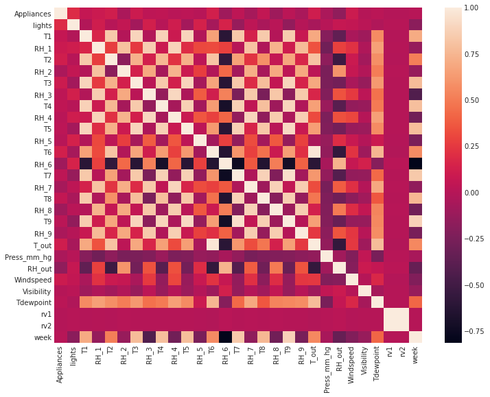

```python
sns.heatmap(data.corr())
```

```python
data.head()
```

|  | date | Appliances | lights | T1 | RH_1 | T2 | RH_2 | T3 | RH_3 | T4 | ... | RH_9 | T_out | Press_mm_hg | RH_out | Windspeed | Visibility | Tdewpoint | rv1 | rv2 | week |
| --- | --- | --- | --- | --- | --- | --- | --- | --- | --- | --- | --- | --- | --- | --- | --- | --- | --- | --- | --- | --- | --- |
| 906 | 2016-01-18 00:00:00 | 60 | 10.0 | 21.823333 | 39.900000 | 20.230000 | 40.0000 | 20.323333 | 39.79 | 21.166667 | ... | 38.400000 | -2.800000 | 763.700000 | 86.0 | 2.0 | 25.0 | -4.900000 | 2.995012 | 2.995012 | 3 |
| 907 | 2016-01-18 00:10:00 | 50 | 10.0 | 21.790000 | 39.933333 | 20.166667 | 40.0900 | 20.390000 | 39.79 | 21.100000 | ... | 38.466667 | -2.883333 | 763.583333 | 86.0 | 2.0 | 25.5 | -4.983333 | 7.407794 | 7.407794 | 3 |
| 908 | 2016-01-18 00:20:00 | 40 | 10.0 | 21.730000 | 40.000000 | 20.075000 | 40.0675 | 20.323333 | 39.79 | 21.100000 | ... | 38.400000 | -2.966667 | 763.466667 | 86.0 | 2.0 | 26.0 | -5.066667 | 3.649394 | 3.649394 | 3 |
| 909 | 2016-01-18 00:30:00 | 30 | 20.0 | 21.666667 | 40.000000 | 20.000000 | 40.0000 | 20.290000 | 39.70 | 21.100000 | ... | 38.466667 | -3.050000 | 763.350000 | 86.0 | 2.0 | 26.5 | -5.150000 | 2.144295 | 2.144295 | 3 |
| 910 | 2016-01-18 00:40:00 | 40 | 0.0 | 21.600000 | 40.193333 | 19.945000 | 40.0000 | 20.260000 | 39.76 | 21.100000 | ... | 38.590000 | -3.133333 | 763.233333 | 86.0 | 2.0 | 27.0 | -5.233333 | 26.123064 | 26.123064 | 3 |

5 rows × 30 columns

```python
new_shape = data.shape
new_shape
```

```
(18144, 30)
```

```python
(old_shape[0] - new_shape[0]) / old_shape[0] * 100
```

```
8.06181910311629
```

- все остальные колонки воспринимаем как `float`

```python
data['lights'] = data['lights'].astype('float')
```

- колонка `Appliances` – целевая переменная `y`

```python
y = data['Appliances']
```

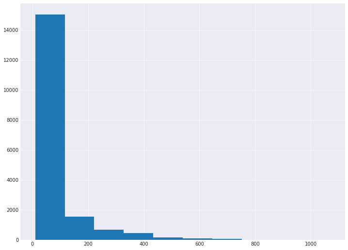

```python
y.hist();
```

```python
y.mean()
```

```
96.0978835978836
```

```python
y.max(), y.median(), y.min()
```

```
(1070, 60.0, 10)
```

```python
y.mode()
```

```
0    50
dtype: int64
```

- всё остальное – `X`, т.е. признаки

```python
data.drop('Appliances', axis=1, inplace=True)
```

```python
data.head()
```

|  | date | lights | T1 | RH_1 | T2 | RH_2 | T3 | RH_3 | T4 | RH_4 | ... | RH_9 | T_out | Press_mm_hg | RH_out | Windspeed | Visibility | Tdewpoint | rv1 | rv2 | week |
| --- | --- | --- | --- | --- | --- | --- | --- | --- | --- | --- | --- | --- | --- | --- | --- | --- | --- | --- | --- | --- | --- |
| 906 | 2016-01-18 00:00:00 | 10.0 | 21.823333 | 39.900000 | 20.230000 | 40.0000 | 20.323333 | 39.79 | 21.166667 | 39.863333 | ... | 38.400000 | -2.800000 | 763.700000 | 86.0 | 2.0 | 25.0 | -4.900000 | 2.995012 | 2.995012 | 3 |
| 907 | 2016-01-18 00:10:00 | 10.0 | 21.790000 | 39.933333 | 20.166667 | 40.0900 | 20.390000 | 39.79 | 21.100000 | 39.826667 | ... | 38.466667 | -2.883333 | 763.583333 | 86.0 | 2.0 | 25.5 | -4.983333 | 7.407794 | 7.407794 | 3 |
| 908 | 2016-01-18 00:20:00 | 10.0 | 21.730000 | 40.000000 | 20.075000 | 40.0675 | 20.323333 | 39.79 | 21.100000 | 39.900000 | ... | 38.400000 | -2.966667 | 763.466667 | 86.0 | 2.0 | 26.0 | -5.066667 | 3.649394 | 3.649394 | 3 |
| 909 | 2016-01-18 00:30:00 | 20.0 | 21.666667 | 40.000000 | 20.000000 | 40.0000 | 20.290000 | 39.70 | 21.100000 | 39.933333 | ... | 38.466667 | -3.050000 | 763.350000 | 86.0 | 2.0 | 26.5 | -5.150000 | 2.144295 | 2.144295 | 3 |
| 910 | 2016-01-18 00:40:00 | 0.0 | 21.600000 | 40.193333 | 19.945000 | 40.0000 | 20.260000 | 39.76 | 21.100000 | 40.000000 | ... | 38.590000 | -3.133333 | 763.233333 | 86.0 | 2.0 | 27.0 | -5.233333 | 26.123064 | 26.123064 | 3 |

5 rows × 29 columns

**[+1]** Визуализируйте последнюю неделю

(убедитесь, что датасет отсортирован по дате)

должен получиться следующий ряд:

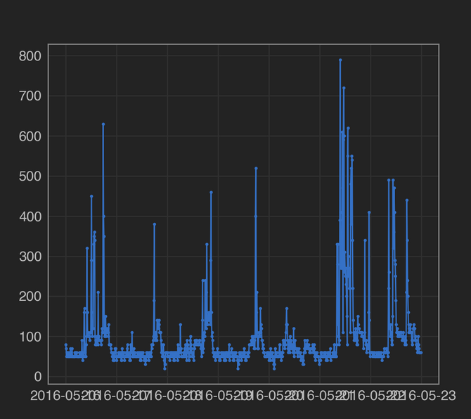

```python
drw = data.loc[data['week'] == 20]
```

```python
drw.shape
```

```
(1008, 29)
```

```python
y.shape
```

```
(18144,)
```

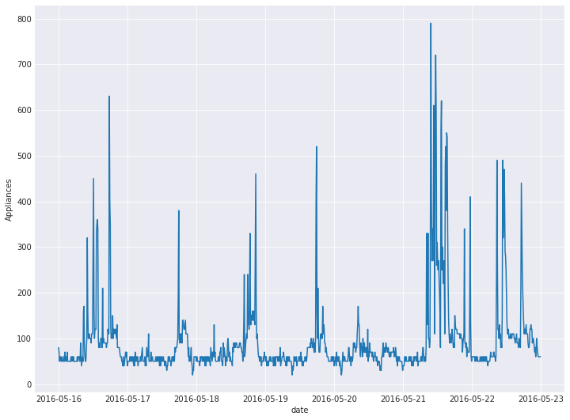

```python
sns.lineplot(x=drw['date'], y=y[y.shape[0] - drw.shape[0]:])
```

## B. Validation

**[+1]** Разобъём датасет на 2 части:

- данные за недели 19-20 – тестовая выборка

```python
X_test = data.loc[(data['week'] >= 19) & (data['week'] <= 20)]
```

- недели 3-18 – обучающая выборка

```python
X_train = data.loc[(data['week'] >= 3) & (data['week'] <= 18)]
```

```python
y_train = y[:X_train.shape[0]]
y_test = y[X_train.shape[0]:]
y_train.shape, y_test.shape
```

```
((16128,), (2016,))
```

```python
X_train.shape, X_test.shape
```

```
((16128, 29), (2016, 29))
```

```python
X_test.shape[0] / X_train.shape[0] == 1 / 8
```

```
True
```

**[+1]** *Как называется данный вид валидации?*

```python
"""
Валидация на отложенных данных (Hold-Out Validation)
"""
```

```
'\nВалидация на отложенных данных (Hold-Out Validation)\n'
```

# C. Feature Extraction

#### Gradient Boosting Machine

**[+2]** Обучим градиентный бустинг (выбрать фреймфорк, с которым привыкли работать – CatBoost, XGBoost, LGBM, H2O и т.д.). Возьмём глубину **D=4**, и количество деревьев **N=200**, остальные параметры по умолчанию / на ваш выбор.

```python
D = 4
N = 200
```

```python
gbr = CatBoostRegressor(num_trees=N,
                        depth=D,
                        grow_policy='SymmetricTree',
                        loss_function='MAE',
                        thread_count=4,
                        learning_rate=0.001)
```

```python
gbr.fit(X_train, y_train)
```

[output not shown]

[output cut: 145 more lines]

[output not shown]

```
<catboost.core.CatBoostRegressor at 0x1da863739d0>
```

```python
gbr.feature_importances_
```

```
array([4.73245797e+00, 5.05430263e+01, 2.23348877e-01, 4.01217161e+00,
       1.01404765e+01, 5.66239064e-02, 2.36170318e-01, 1.57667385e-01,
       3.70232832e-02, 4.94265309e-01, 1.34567838e-01, 3.51862188e-01,
       1.93454187e+00, 6.82667617e-01, 1.66995124e-02, 2.36739559e-01,
       3.23700219e+00, 9.81446706e+00, 1.00923545e+00, 2.32300614e+00,
       1.06089462e+00, 2.19207545e-01, 3.42668613e+00, 5.55869733e-01,
       3.12220626e-02, 0.00000000e+00, 0.00000000e+00, 0.00000000e+00,
       4.33209902e+00])
```

```python
y_pred = gbr.predict(X_test)
```

```python
mean_absolute_error(y_test, y_pred)
```

```
40.48424016135518
```

```python
np.sqrt(mean_squared_error(y_test, y_pred))
```

```
92.5049801191593
```

**[+1]** *В чём отличие между leaf-wise tree и depth-wise tree?*

```python
"""
Leaf-wise и depth-wise - это методы построения деревьев. Если используется leaf-wise построение дерева, то деревья строятся
по листьям. Лист выбирается тот при, котором потери сводятся к минимуму.
В depth-wise деревьях построение происходит по уровням и каждый узел разделяет данные и
дает приоритет тем узлам, которые ближе к корню.
Эти метода подходят разным данным, а именно если данных не много, то лучше использовать depth-wise tree и иначе,
если данных давольно много, то лучше использовать leaf-wise. Потому что lead-wise может переобучиться на малом
количесве данных. Так же leaf-wise tree лучше подходит большим выборкам потому что он строит деревья бысрее.
"""
```

```
'\nLeaf-wise и depth-wise - это методы построения деревьев. Если используется leaf-wise построение дерева, то деревья строятся\nпо листьям. Лист выбирается тот при, котором потери сводятся к минимуму.\nВ depth-wise деревьях построение происходит по уровням и каждый узел разделяет данные и\nдает прио…
```

**[+1]** Визуализировать feature importances (оставить топ-10) в виде:

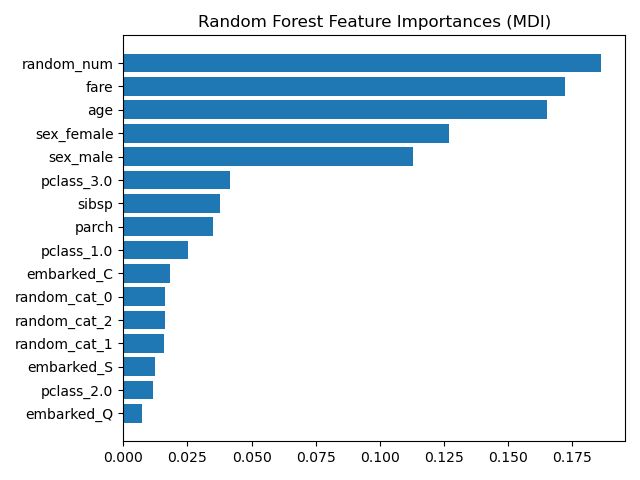

```python
fi = pd.DataFrame(gbr.feature_importances_, X_train.columns, columns=['coef']).sort_values(by='coef', ascending=False)
```

```python
fi
```

|  | coef |
| --- | --- |
| lights | 50.543026 |
| T2 | 10.140476 |
| RH_8 | 9.814467 |
| date | 4.732458 |
| week | 4.332099 |
| RH_1 | 4.012172 |
| RH_out | 3.426686 |
| T8 | 3.237002 |
| RH_9 | 2.323006 |
| T6 | 1.934542 |
| T_out | 1.060895 |
| T9 | 1.009235 |
| RH_6 | 0.682668 |
| Windspeed | 0.555870 |
| RH_4 | 0.494265 |
| RH_5 | 0.351862 |
| RH_7 | 0.236740 |
| T3 | 0.236170 |
| T1 | 0.223349 |
| Press_mm_hg | 0.219208 |
| RH_3 | 0.157667 |
| T5 | 0.134568 |
| RH_2 | 0.056624 |
| T4 | 0.037023 |
| Visibility | 0.031222 |
| T7 | 0.016700 |
| Tdewpoint | 0.000000 |
| rv1 | 0.000000 |
| rv2 | 0.000000 |

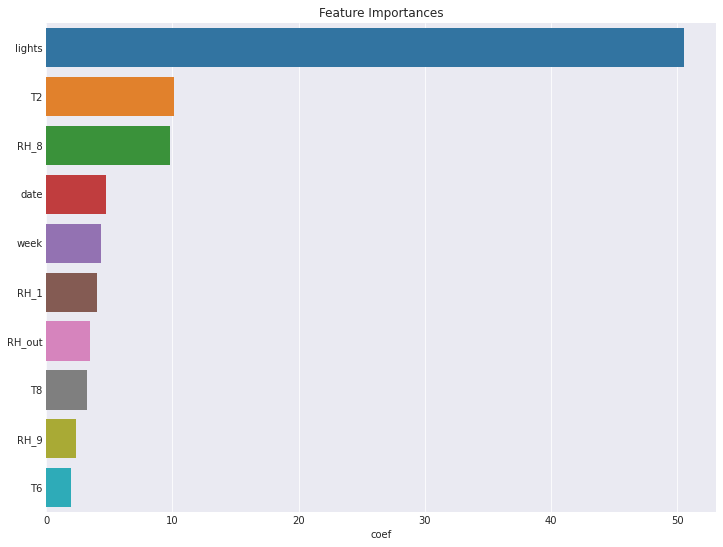

```python
sns.barplot(data=fi[:10], x='coef', y=fi.T.columns[:10])
plt.title('Feature Importances')
```

**[+1]** *Как считается feature importance в выбранном вами бустинге?*

```python
"""
По умолчанию в Catboost важность признаков вычисляется методом PredictionValuesChange.
Для каждого признака вычисляется, насколько в среднем прогноз изменяется при изменении значения признака.
То есть значение признака будет больше, если при изменении значения признака
в среднем больше изменилось значния предсказания.
"""
```

```
'\nПо умолчанию в Catboost важность признаков вычисляется методом PredictionValuesChange. \nДля каждого признака вычисляется, насколько в среднем прогноз изменяется при изменении значения признака.\nТо есть значение признака будет больше, если при изменении значения признака\nв среднем больше измени…
```

```python
"""
Пары листьев, которые сравниваются, имеют разные значения разбиения в узле на пути к этим листьям.
Если условие разбиения выполнено, объект переходит в левое поддерево, в противном случае - в правое.

Если модель использует комбинацию некоторых входных признаков вместо того, чтобы использовать их по отдельности,
вычисляется и выводится средняя значимость этих признаков.

Сначала рассчитывается важность признака для комбинации этих признаков.
Затем полученное значение делится на количество признаков в комбинации и присваивается каждому из признаков.
"""
```

```
'\nПары листьев, которые сравниваются, имеют разные значения разбиения в узле на пути к этим листьям. \nЕсли условие разбиения выполнено, объект переходит в левое поддерево, в противном случае - в правое.\n\nЕсли модель использует комбинацию некоторых входных признаков вместо того, чтобы использоват…
```

[+1] Сколько суммарно листьев у depth-wise tree глубины D? (обозначим ответ за L)

- Листьями являются те узлы, у которых нет потомков. Посколько у нас строяться полные сбалансированные деревья, то количество листев в дереве глубины D будет равно $L = {2}^{{D}}$

```python
L = 2**D
L
```

```
16
```

Каждый объект, когда прогоняется через бустинг, попадает в конкретный лист в каждом дереве. Если в каждом дереве L листьев, тогда всего у бустинга (N * L) листьев. Таким образом, объект можно представить как вектор из N индексов, где на i-й позиции номер листа, в который попал объект в i-ом дереве.

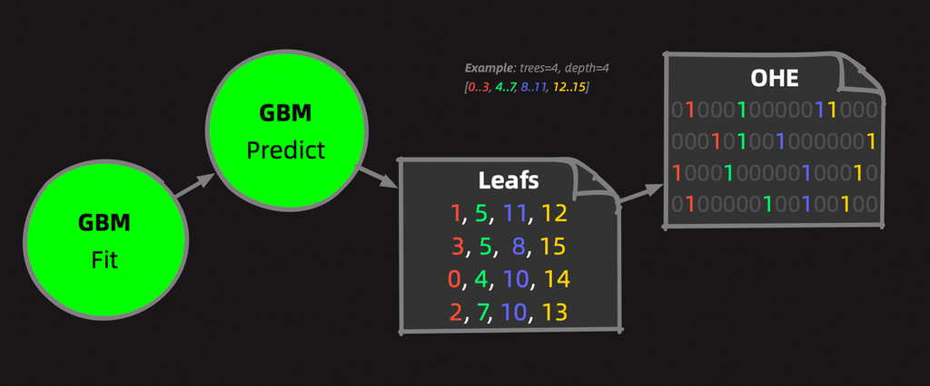

**[+2]** Для тренировочной и валидационной части мы сделаем предсказания. Но не в виде прогноза целевой переменной, а в виде перевода в новое признаковое пространство.

Каждый объект, когда прогоняется через бустинг, попадает в конкретный лист в каждом дереве. Если в каждом дереве L листьев, тогда всего у бустинга (N * L) листьев. Таким образом, объект можно представить как вектор из N индексов, где на i-й позиции номер листа, в который попал объект в i-ом дереве.

```python
leaf_indexs_train = gbr.calc_leaf_indexes(X_train, ntree_start=0, thread_count=-1, verbose=False)
leaf_indexs_test = gbr.calc_leaf_indexes(X_test, ntree_start=0, thread_count=-1, verbose=False)
```

```python
leaf_indexs_train.shape, leaf_indexs_test.shape
```

```
((16128, 200), (2016, 200))
```

**[+2]** Перевести индексы листьев из пространства `[0...L)` (индексы уникальны в рамках дерева) в формат `[0...N*L)` (индексы уникальны в рамках всего ансамбля).

- допустим мы имеем 3 дерева, объект попал во 2-й лист в первом дереве, в 5-й во втором и в 0-й в третьем.
- на выходе получаем вектор **[2, 5, 0]** (индексы - локальные по каждому дереву)
- его необходимо перевести в **[2, 1*L+5, 2*L+0]** (индексы - глобальные по всему бустингу)
- пример результата на диаграмме

Вывести первые 10 строк и 10 стобцов старой и новой матрицы индексов (если использована кросс-валидация, по каждому фолду)

- размерности старой и новой матрицы индексов
- комментарием в ячейке полученные L и N*L

```python
ensemble_indexs_train = np.array([np.arange(N) * L] * leaf_indexs_train.shape[0]) + leaf_indexs_train
ensemble_indexs_test = np.array([np.arange(N) * L] * leaf_indexs_test.shape[0]) + leaf_indexs_test
```

```python
leaf_indexs_train[:10, :10], leaf_indexs_test[:10, :10]
```

```
(array([[ 7,  5, 15,  7,  3,  5,  9,  3,  5,  9],
        [ 7,  5, 15,  7,  3,  5,  9,  3,  5,  9],
        [ 7,  5, 15,  7,  3,  5,  9,  3,  5,  9],
        [ 7,  5, 15,  7,  3,  5,  9,  3,  5,  9],
        [ 6,  4, 14,  5,  1,  4,  8,  1,  4,  8],
        [ 6,  4, 14,  5,  1,  4,  8,  1,  4,  8],
        [ 6,  4, 14,  5,  1,  4,  8,  1,  4,  8],
        [ 6,  4, 14,  5,  1,  4,  8,  0,  4,  8],
        [ 7,  5, 15,  6,  3,  5,  9,  2,  5,  9],
        [ 6,  4, 14,  4,  1,  4,  8,  0,  4,  8]], dtype=uint32),
 array([[10, 14,  8,  9,  1, 10, 14,  5, 10, 14],
        [10, 14,  8, 13,  1, 10, 14,  5, 10, 14],
        [10, 14,  8, 13,  1, 10, 14,  5, 10, 14],
        [10, 14,  8,  9,  1, 10, 14,  5, 10, 14],
        [10, 14,  8,  9,  1, 10, 14,  5, 10, 14],
        [10, 14,  8,  9,  1, 10, 14,  5, 10, 14],
        [10, 14,  8,  9,  1, 10, 14,  5, 10, 14],
        [10, 14,  8,  9,  1, 10, 14,  5, 10, 14],
        [10, 14,  8,  9,  1, 10, 14,  5, 10, 14],
        [10, 14,  8,  9,  1, 10, 14,  5, 10, 14]], dtype=uint32))
```

```python
ensemble_indexs_train[:10, :10], ensemble_indexs_test[:10, :10]
```

```
(array([[  7,  21,  47,  55,  67,  85, 105, 115, 133, 153],
        [  7,  21,  47,  55,  67,  85, 105, 115, 133, 153],
        [  7,  21,  47,  55,  67,  85, 105, 115, 133, 153],
        [  7,  21,  47,  55,  67,  85, 105, 115, 133, 153],
        [  6,  20,  46,  53,  65,  84, 104, 113, 132, 152],
        [  6,  20,  46,  53,  65,  84, 104, 113, 132, 152],
        [  6,  20,  46,  53,  65,  84, 104, 113, 132, 152],
        [  6,  20,  46,  53,  65,  84, 104, 112, 132, 152],
        [  7,  21,  47,  54,  67,  85, 105, 114, 133, 153],
        [  6,  20,  46,  52,  65,  84, 104, 112, 132, 152]], dtype=int64),
 array([[ 10,  30,  40,  57,  65,  90, 110, 117, 138, 158],
        [ 10,  30,  40,  61,  65,  90, 110, 117, 138, 158],
        [ 10,  30,  40,  61,  65,  90, 110, 117, 138, 158],
        [ 10,  30,  40,  57,  65,  90, 110, 117, 138, 158],
        [ 10,  30,  40,  57,  65,  90, 110, 117, 138, 158],
        [ 10,  30,  40,  57,  65,  90, 110, 117, 138, 158],
        [ 10,  30,  40,  57,  65,  90, 110, 117, 138, 158],
        [ 10,  30,  40,  57,  65,  90, 110, 117, 138, 158],
        [ 10,  30,  40,  57,  65,  90, 110, 117, 138, 158],
        [ 10,  30,  40,  57,  65,  90, 110, 117, 138, 158]], dtype=int64))
```

```python
leaf_indexs_train.shape, leaf_indexs_test.shape
```

```
((16128, 200), (2016, 200))
```

```python
ensemble_indexs_train.shape, ensemble_indexs_test.shape
```

```
((16128, 200), (2016, 200))
```

```python
# 16, 3200: L, L * N
```

**[+2]** предыдущее задание должно быть выполнено с помощью матричной алгебры numpy

**One-Hot Encoding**

**[+2]** Имея глобальные индексы листьев, можем перевести их в пространство нулей и единиц:

- пусть на предыдущем шаге мы получили индексы [1, 4, 7), а всего индексов 8
- перевести их в формат [0, 1, 0, 0, 1, 0, 0, 1]

Это и будет новым признаковым пространством, в которое мы перевели датасет с помощью градиентного бустинга

```python
ohe_train = np.ndarray(shape=(ensemble_indexs_train.shape[0], N * L),
                                buffer=np.zeros(N * L * ensemble_indexs_train.shape[0],
                                                dtype=np.int), dtype=np.int)
```

```python
ohe_test = np.ndarray(shape=(ensemble_indexs_test.shape[0], N * L),
                                buffer=np.zeros(N * L * ensemble_indexs_test.shape[0],
                                                dtype=np.int), dtype=np.int)
```

```python
ohe_train.shape, ohe_test.shape
```

```
((16128, 3200), (2016, 3200))
```

```python
for obj, indx in zip(ohe_train, ensemble_indexs_train):
    obj[indx] = 1
```

```python
for obj, indx in zip(ohe_test, ensemble_indexs_test):
    obj[indx] = 1
```

# D. Linear Regression

**LinReg**

**[+1]** поверх полученной матрицы из нулей и единиц обучаем линейную регрессию

**[+1]** добавить L1 регуляризацию, λ=0.666

```python
from sklearn.linear_model import LinearRegression
from sklearn.linear_model import Lasso
```

```python
linreg = LinearRegression(n_jobs=-1)
```

```python
%%time
linreg.fit(ohe_train, y_train)
```

```
Wall time: 30.5 s
```

```
LinearRegression(n_jobs=-1)
```

```python
linreg_pred = linreg.predict(ohe_test)
```

```python
mean_absolute_error(y_test, linreg_pred)
```

```
304031175389.5943
```

- Тут точно нельзя без регуляризации
- Необходимо выбрасить большое количество признаков

```python
np.sqrt(mean_squared_error(y_test, linreg_pred))
```

```
1516538569309.5227
```

```python
len(set(linreg.coef_))
```

```
3111
```

```python
lassolinreg = Lasso(alpha=0.666, random_state=19)
```

```python
%%time
lassolinreg.fit(ohe_train, y_train)
```

```
Wall time: 6.13 s
```

```
Lasso(alpha=0.666, random_state=19)
```

```python
lasso_pred = lassolinreg.predict(ohe_test)
```

```python
mean_absolute_error(y_test, lasso_pred)
```

```
52.52095523832967
```

```python
np.sqrt(mean_squared_error(y_test, lasso_pred))
```

```
84.77732439135855
```

```python
# MAE = 52.52095523832967, MSE = 84.77732439135855
```

- **[+1]** *какой % признаков отключился?*
- **[+1]** *в чём разница между L1 и L2 регуляризацией? почему L1 можно использовать для отбора признаков, а L2 нельзя?*

```python
len(set(lassolinreg.coef_))
```

```
74
```

```python
100 - len(lassolinreg.coef_[lassolinreg.coef_ != 0]) / 3200 * 100
```

```
97.71875
```

```python
"""
97.71875% признаков отключилось.

L2 регуляризация сильнее штрафует, за выбросы в данных, чем L1 регуляризация

L1 регуляризация обнуляет признаки и поэтому она сильно улучшила качество на валидационной выборке.

L2 регуляризацию нельзя использовать для отборка признаков, потому что она их не обнуляет и держит их с очень маленькими значениями.
"""
```

```
'\n97.71875% признаков отключилось.\n\nL2 регуляризация сильнее штрафует, за выбросы в данных, чем L1 регуляризация\n\nL1 регуляризация обнуляет признаки и поэтому она сильно улучшила качество на валидационной выборке.\n\nL2 регуляризацию нельзя использовать для отборка признаков, потому что она их …
```

**[+1]** визуализируйте scatter plot весов регрессии для первых 10 деревьев (сами веса + их модули) – должно получиться 10 * L точек

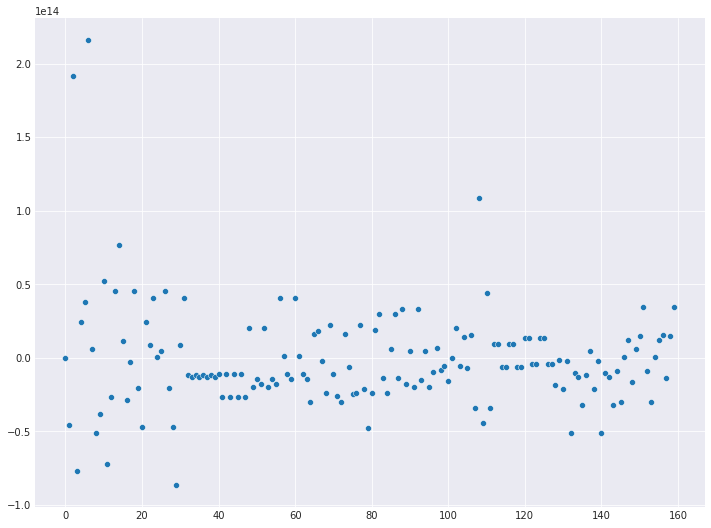

```python
sns.scatterplot(data=linreg.coef_[:10 * L])
```

**[+1]** Визуализировать реальный таргет и его прогноз (последние 100 точек, сортировка по дате). если использована кросс-валидация, то по график нужен для каждого фолда

```python
target = pd.Series(data=y_test[y_test.shape[0] - 100:].values, name='Appliances')
predict = pd.Series(data=lasso_pred[lasso_pred.shape[0] - 100:], name='Predict')
```

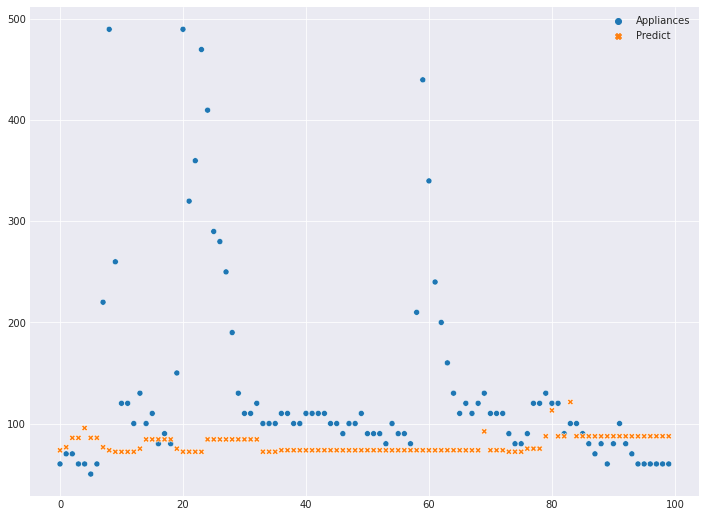

```python
sns.scatterplot(data=[target, predict])
```

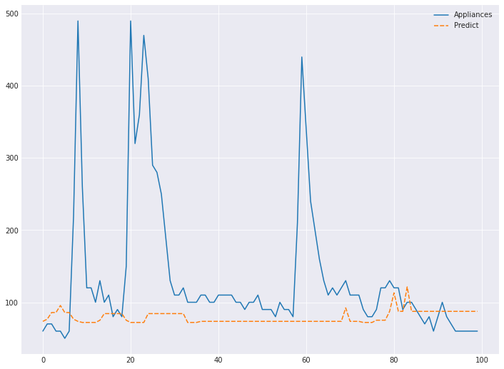

```python
ax = sns.lineplot(data=[target, predict])
```

**Confidence Bound**